# ML Algorithms for classification

Slides – http://bit.ly/2q9NPSU

## Classification

Email: Spam/Not Spam?

Online transactions: Fraudulent(Yes/No)?

Tumor: Malignant/Benign?

Loan Default: (Yes/No)

\[ y \in \{ 0,1 \} ~\left\{ \begin{array}{ll} 0 & \mbox{Negative class (e.g. able to pay loan)} \\ 1 & \mbox{Positive class (e.g. unable to pay loan)} \end{array} \right. \]

## Aims of this lesson

Understand what a logistic regression is, how to prepare data for a logistic regression, and how to evaluate a model.

A logistic regression is a linear regression, applied to categorical outcomes by using a transformation function.

But, why do we need a transformation function, why not plain, old, linear regression?

We fit a simple linear model `default ~ balance` to the Default dataset from the `ISLR` package.

## Why do we need a transformation function?

Recall that:

The linear regression model is nothing but the expected value of the target given the realisation of the predictors \[ \mathbb{E}\left(Y| X=x \right) = \beta^TX\] Since \(Y\) is limited to values of \(0\) and \(1\) , we have

\[ \mathbb{E}\left(Y| X=x \right) = P\left(Y| X=x \right)\]

It would then seem reasonable that \(\beta^TX\) is a reasonable estimate of \(P\left(Y| X=x \right)\). We test this on the **Default** data.

## Why do we need a transformation function?

```r
model_lm = lm(default ~ balance, data = default_train_lm)
```

Everything seems to be working, until we plot the results.

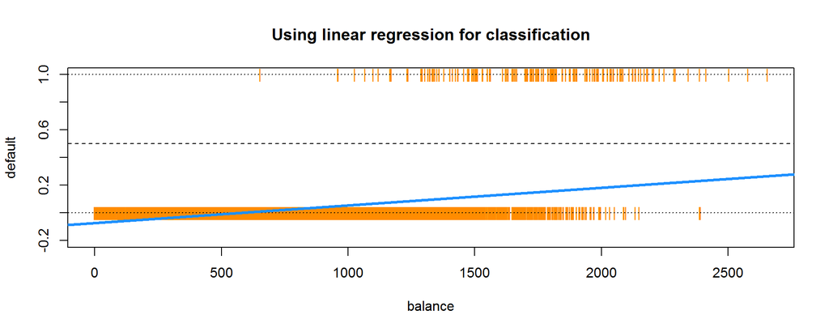

## Why do we need a transformation function?

Two issues arise. First, all of the predicted probabilities are below 0.5 That means, we would classify every observation as a "No Default". This is certainly possible, but not what we would expect.

```r
all(predict(model_lm) < 0.5)
```

```
#> [1] TRUE
```

The next, and bigger issue, is predicted probabilities less than 0.

```r
any(predict(model_lm) < 0)
```

```
#> [1] TRUE
```

## Which transformation function?

- The linear hypothesis \(Y = h_{\beta}(X)= \beta^TX\) may take values from \(-\infty\) to \(\infty\)
- We want \(0 \leq h_{\beta}(X)\leq 1\)
- \(h_{\beta}(X)= g(\beta^TX)\) and \(g(z) = \frac{1}{1+e^{-z}}\)
- Called Sigmoid or Logistic function

[figure not shown]

## Fitting the logistic model

- The model is fit by numerically maximizing the likelihood.

```r
model_glm = glm(default ~ balance, data = default_train, family = "binomial")
```

First, we can obtain the fitted coefficients the same way we did with linear regression.

```r
coef(model_glm)
```

```
#>   (Intercept)       balance
#> -10.452182876   0.005367655
```

```r
head(predict(model_glm))
```

```
#>       9149       9370       2861       8302       6415       5189
#> -6.9616496 -0.7089539 -4.8936916 -9.4123620 -9.0416096 -7.3600645
```

The next thing we should understand is how the `predict()` function works with `glm()`. So, let's look a some predictions.

## How the `predict()` function works

By default, predict.glm() uses type = "link".

```r
head(predict(model_glm, type = "link"))
```

```
#>       9149       9370       2861       8302       6415       5189
#> -6.9616496 -0.7089539 -4.8936916 -9.4123620 -9.0416096 -7.3600645
```

That is, `R` is returning

\[\hat{\beta_0} + \hat{\beta_1}x_1 + \hat{\beta_1}x_1 + \hat{\beta_2}x_2+ \cdots+ \hat{\beta_p}x_p\] for each observation.

These are not predicted probabilities. To obtain the predicted probabilities

\[\hat{p}(x)=\hat{P}\left(Y=1 || X=x \right)\]

## How the `predict()` function works

```r
head(predict(model_glm, type = "response"))
```

```
#>         9149         9370         2861         8302         6415
#> 9.466353e-04 3.298300e-01 7.437969e-03 8.170105e-05 1.183661e-04
#>         5189
#> 6.357530e-04
```

Note that these are probabilities, **not** classifications. To obtain classifications, we will need to compare to the correct cutoff value with an `ifelse()` statement.

```r
model_glm_pred = ifelse(predict(model_glm, type = "link") > 0, "Yes", "No")
# model_glm_pred = ifelse(predict(model_glm, type = "response") > 0.5, "Yes", "No")
```

Once we have classifications, we can calculate metrics such as accuracy.

```r
mean(model_glm_pred == default_train$default) # train accuracy
```

```
#> [1] 0.9722
```

## Confusion matrix

[figure not shown]

**true positives (TP)**: These are cases in which we predicted yes (Defalut), and they are Defaulted.

**true negatives (TN):** We predicted will NOT default, but they will NOT default.

**false positives (FP):** We predicted Defaulted, but they don't actually Defaulted. (Also known as a "Type I error.")

**false negatives (FN):** We predicted NOT Defaulted, but they actually do NOT Defaulted. (Also known as a "Type II error.")

## Other performance metrics

**Accuracy:** Overall, how often is the classifier correct?

- \(\frac{TP+TN}{\mbox{total}} = \frac{100+50}{165} = 0.91\)

**Misclassification rate:** Overall, how often is it wrong?

- \(\frac{FP+FN}{\mbox{total}} = \frac{(10+5)}{165} = 0.09\)
- equivalent to 1 minus Accuracy also known as *error rate*

**True positive rate:** When it's actually yes, how often does it predict yes?

- \(\frac{TP}{\mbox{actual yes}} = \frac{100}{105} = 0.95\) also known as *Sensitivity* or *Recall*

## Other performance metrics

**False Positive Rate**: When it's actually no, how often does it predict yes?

\(\frac{FP}{\mbox{actual no}} = \frac{10}{60} = 0.17\)

**Specificity:** When it's actually no, how often does it predict no?

\(\frac{TN}{\mbox{actual no}} = 50/60 = 0.83\) equivalent to 1 minus False Positive Rate

**Precision:** When it predicts yes, how often is it correct?

\(\frac{TP}{\mbox{predicted yes}} = 100/110 = 0.91\)

For more performance metrics take a look at the [InformationValue R package](http://bit.ly/1hJ6scb)

## Back to our Default model

Let calculate some metrics such as accuracy.

```r
mean(model_glm_pred == default_train$default) # train accuracy
```

```
#> [1] 0.9722
```

We may use the `table()` and `confusionMatrix()` functions can be used to quickly obtain many more metrics.

```r
train_tab = table(predicted = model_glm_pred, actual = default_train$default)
library(caret)
train_con_mat = confusionMatrix(train_tab, positive = "Yes")
c(train_con_mat$overall["Accuracy"],
  train_con_mat$byClass["Sensitivity"],
  train_con_mat$byClass["Specificity"])
```

```
#>    Accuracy Sensitivity Specificity
#>   0.9722000   0.2738095   0.9964818
```

## Why the logistic model is better

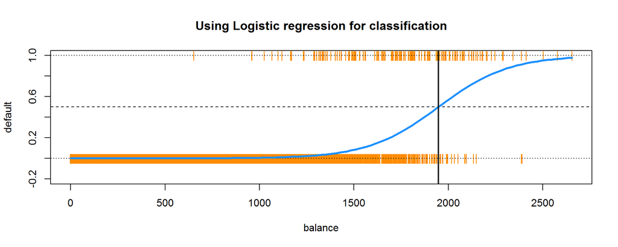

- The blue "curve" is the predicted probabilities given by the fitted logistic regression: \[ \hat{p}({\bf x}) = P\left(Y = 1 \mid {\bf X = x}\right) \]

## Why the logistic model is better

- The solid vertical black line represents the **[decision boundary](http://bit.ly/2pf9uJY)**, the `balance` that obtains a predicted probability of 0.5. In this case `balance` = 1947.252994.

\[ \hat{p}({\bf x}) = \hat{P}[Y = 1 \mid {\bf X = x}] = 0.5 \] Or \[ \hat{\beta}_0 + \hat{\beta}_1 x_1 = 0. \] Thus, for logistic regression with a single predictor, the decision boundary is given by the *point* \(x_1 = \frac{-\hat{\beta}_0}{\hat{\beta}_1}\)

## Receiver Operating Characteristic (ROC)

- Recall In our simple model above we classified *Defaulted* vs *NOT Defaulted* based on a probability threshold/cutoff of *Default* equal to \(\theta =0.5\).
- The choice of of this threshold impacts the values of all performance metrics, in particular the false positives (FP) and false negatives (FN).
- For the purpose of visualizing and quantifying the impact of a threshold on the FP/FN-trade-off the ROC curve was introduced.

\[ROC_x(\theta) = FPR(\theta)= \frac{FP(\theta)}{FP(\theta)+TN(\theta)}= \frac{FP(\theta)}{ \#N}\] \[ROC_y(\theta) = TPR(\theta)= \frac{TP(\theta)}{FN(\theta)+TP(\theta)}= \frac{TP(\theta)}{\#P}\]

## Receiver Operating Characteristic (ROC)

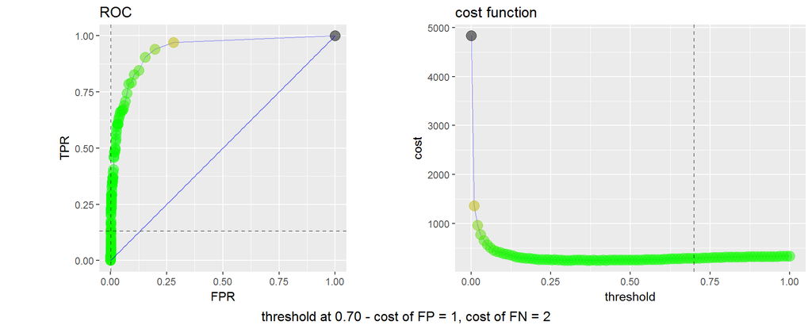

- The dashed lines indicate the location of the (FPR, TPR) corresponding to a threshold of 0.7.

## Receiver Operating Characteristic (ROC)

- The low corner (0,0) is associated with a threshold of 1 and the top corner (1,1) with a threshold of 0.
- The cost function and the corresponding coloring of the ROC points illustrate that an optimal FPR and TPR combination is determined by the associated cost.
- Depending on the use case false negatives might be more costly than false positive or vice versa. Here I assumed a cost of 1 for FP cases and a cost of 2 for FN cases.

## Summary

- Linear regression models are not suitable for classification problems.
- The linear assumption can be replaced buy the logistic function to avoid the linear assumption shortcomings
- Most of statistical methods (RSS, p-values, dimension reduction, subsets selection, ridge, lasso, etc.) applied to the linear regression models remains valid for the logistic model.
- New classification performance metrics are used to assess the discrimination power of the logistic model

## Thank you!

- Slides: http://bit.ly/2q9NPSU
- GitHub: https://github.com/trefoil-ml
- Twitter: https://twitter.com/trefoilML
- Email: info@tridata.nl or hzmarrou@gmail.com